# data_wrangling_ii_strings_and_factors

Boya Guo

10/16/2018

String: just the text, character varaible, no underlying structures

Factor: Numeric structure with character labels sitting on top. For variable with only a few collection of categories.

str_detect detects “jeff” to see which one in the string matches “jeff”, str_place will replace if find “jeff”. We know eaxactly what we want to replace.

```r
string_vec = c("my", "name", "is", "jeff")

str_detect(string_vec, "jeff")
```

```
## [1] FALSE FALSE FALSE  TRUE
```

```r
str_replace(string_vec, "jeff", "Jeff")
```

```
## [1] "my"   "name" "is"   "Jeff"
```

str_detect(string_vec, “i think”) detects every sentence with “i think” str_detect(string_vec, “^i think”) detects only those begin with “i think” str_detect(string_vec, “i think$”) detects those end with “i think”

```r
string_vec = c(
  "i think we all rule for participating",
  "i think i have been caught",
  "i think this will be quite fun actually",
  "it will be fun, i think"
  )

str_detect(string_vec, "i think")
```

```
## [1] TRUE TRUE TRUE TRUE
```

```r
str_detect(string_vec, "^i think")
```

```
## [1]  TRUE  TRUE  TRUE FALSE
```

```r
str_detect(string_vec, "i think$")
```

```
## [1] FALSE FALSE FALSE  TRUE
```

```r
string_vec = c(
  "Y'all remember Pres. HW Bush?",
  "I saw a green bush",
  "BBQ and Bushwalking at Molonglo Gorge",
  "BUSH!!"
  )

str_detect(string_vec,"[Bb]ush")
```

```
## [1]  TRUE  TRUE  TRUE FALSE
```

```r
string_vec = c(
  '7th inning stretch',
  '1st half soon to begin. Texas won the toss.',
  'she is 5 feet 4 inches tall',
  '3AM - cant sleep :('
  )

str_detect(string_vec, "^[0-9][a-zA-Z]")
```

```
## [1]  TRUE  TRUE FALSE  TRUE
```

str_detect(string_vec, “7.11”) selects 7 follows by everything and follows by 11

```r
string_vec = c(
  'Its 7:11 in the evening',
  'want to go to 7-11?',
  'my flight is AA711',
  'NetBios: scanning ip 203.167.114.66'
  )

str_detect(string_vec, "7.11")
```

```
## [1]  TRUE  TRUE FALSE  TRUE
```

```r
string_vec = c(
  'The CI is [2, 5]',
  ':-]',
  ':-[',
  'I found the answer on pages [6-7]'
  )

str_detect(string_vec, "\\[")
```

```
## [1]  TRUE FALSE  TRUE  TRUE
```

### PULSE data

This is the way that we recommend you to tidy the PULSE dataset

```r
pulse_data = haven::read_sas("./data/public_pulse_data.sas7bdat") %>%
  janitor::clean_names() %>%
  gather(key = visit, value = bdi, bdi_score_bl:bdi_score_12m) %>%
  mutate(visit = str_replace(visit, "bdi_score_", ""),
         visit = str_replace(visit, "bl", "00m"),
         visit = fct_relevel(visit, str_c(c("00", "01", "06", "12"), "m"))) %>%
  arrange(id, visit)
print(pulse_data, n = 12)
```

```
## # A tibble: 4,348 x 5
##       id   age sex   visit   bdi
##    <dbl> <dbl> <chr> <fct> <dbl>
##  1 10003  48.0 male  00m       7
##  2 10003  48.0 male  01m       1
##  3 10003  48.0 male  06m       2
##  4 10003  48.0 male  12m       0
##  5 10015  72.5 male  00m       6
##  6 10015  72.5 male  01m      NA
##  7 10015  72.5 male  06m      NA
##  8 10015  72.5 male  12m      NA
##  9 10022  58.5 male  00m      14
## 10 10022  58.5 male  01m       3
## 11 10022  58.5 male  06m       8
## 12 10022  58.5 male  12m      NA
## # ... with 4,336 more rows
```

### NSDUH data

Read in the data from website

```r
url = "http://samhda.s3-us-gov-west-1.amazonaws.com/s3fs-public/field-uploads/2k15StateFiles/NSDUHsaeShortTermCHG2015.htm"
drug_use_xml = read_html(url)

table_marj = (drug_use_xml %>% html_nodes(css = "table")) %>%
  .[[1]] %>%
  html_table() %>%
  slice(-1) %>%
  as_tibble()
```

Clean up the imported data

Removes any string contains p-value using “-contains”

```r
data_marj =
  table_marj %>%
  select(-contains("P Value")) %>%
  gather(key = key, value = percent, -State) %>%
  separate(key, into = c("age", "year"), sep = "\\(") %>%
  mutate(year = str_replace(year, "\\)", ""),
         percent = str_replace(percent, "[a-c]$", ""),
         percent = as.numeric(percent)) %>%
  filter(!(State %in% c("Total U.S.", "Northeast", "Midwest", "South", "West")))
```

Now we have tidy data, we could start making some plots

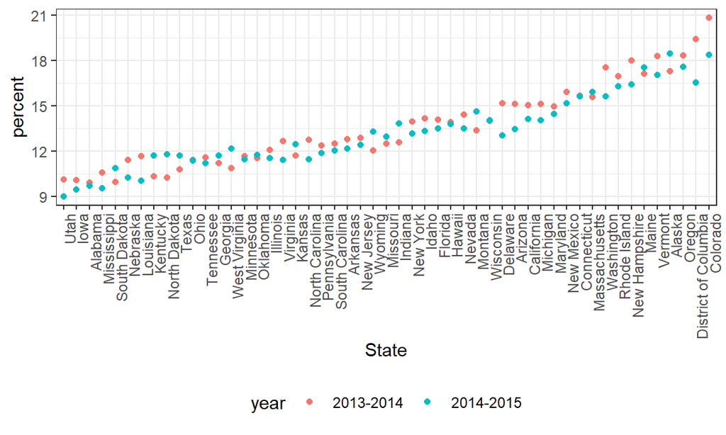

```r
data_marj %>%
  filter(age == "12-17") %>%
  mutate(State = fct_reorder(State, percent)) %>%
  ggplot(aes(x = State, y = percent, color = year)) +
    geom_point() +
    theme(axis.text.x = element_text(angle = 90, hjust = 1))
```